# SARS-CoV-2 in Gibraltar

#### Emergency Room

```
                             OLS Regression Results
===============================================================================
Dep. Variable:     Emergency_Room_Sqrt   R-squared:                       0.662
Model:                             OLS   Adj. R-squared:                  0.657
Method:                  Least Squares   F-statistic:                     139.1
Date:                 Sat, 10 Apr 2021   Prob (F-statistic):           2.17e-18
Time:                         20:59:13   Log-Likelihood:                -148.07
No. Observations:                   73   AIC:                             300.1
Df Residuals:                       71   BIC:                             304.7
Df Model:                            1
Covariance Type:             nonrobust
==============================================================================
                 coef    std err          t      P>|t|      [0.025      0.975]
------------------------------------------------------------------------------
const          6.6442      0.441     15.063      0.000       5.765       7.524
Day           -0.1222      0.010    -11.794      0.000      -0.143      -0.102
==============================================================================
Omnibus:                        2.431   Durbin-Watson:                   0.043
Prob(Omnibus):                  0.297   Jarque-Bera (JB):                2.401
Skew:                           0.415   Prob(JB):                        0.301
Kurtosis:                       2.686   Cond. No.                         86.1
==============================================================================

Notes:
[1] Standard Errors assume that the covariance matrix of the errors is correctly specified.
y =  -0.12217248227871125 x +  6.6441581929215054
```

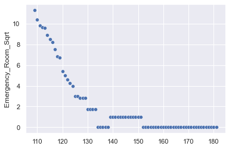

```
No data points after 2021-03-14 00:00:00
```

```python
gibraltar.predict_metric(gibraltar.infection_decline.Day,
                         gibraltar.infection_decline.Emergency_Room_Sqrt,
                         gibraltar.infection_pivot_date,
                         'First Dose',
                         'Emergency Room Occupancy')
```

### Post-Second Dose

#### Active Cases

```
                            OLS Regression Results
==============================================================================
Dep. Variable:      Active_Cases_Sqrt   R-squared:                       0.665
Model:                            OLS   Adj. R-squared:                  0.659
Method:                 Least Squares   F-statistic:                     112.9
Date:                Sat, 10 Apr 2021   Prob (F-statistic):           3.85e-15
Time:                        20:59:13   Log-Likelihood:                -122.21
No. Observations:                  59   AIC:                             248.4
Df Residuals:                      57   BIC:                             252.6
Df Model:                           1
Covariance Type:            nonrobust
==============================================================================
                 coef    std err          t      P>|t|      [0.025      0.975]
------------------------------------------------------------------------------
const         11.0543      0.515     21.458      0.000      10.023      12.086
Day           -0.1587      0.015    -10.628      0.000      -0.189      -0.129
==============================================================================
Omnibus:                        5.356   Durbin-Watson:                   0.036
Prob(Omnibus):                  0.069   Jarque-Bera (JB):                5.021
Skew:                           0.715   Prob(JB):                       0.0812
Kurtosis:                       2.986   Cond. No.                         69.9
==============================================================================

Notes:
[1] Standard Errors assume that the covariance matrix of the errors is correctly specified.
y =  -0.1587112667197988 x +  11.054333052307902
```

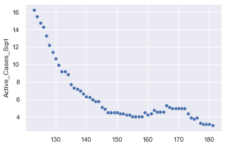

```
No data points after 2021-04-12 00:00:00
```

```python
gibraltar.predict_metric(gibraltar.infection_decline_second_dose.Day,
                         gibraltar.infection_decline_second_dose.Active_Cases_Sqrt,
                         gibraltar.second_dose_date,
                         'Second Dose',
                         'Active Cases')
```

#### Self Isolation

```
                             OLS Regression Results
===============================================================================
Dep. Variable:     Self_Isolation_Sqrt   R-squared:                       0.466
Model:                             OLS   Adj. R-squared:                  0.456
Method:                  Least Squares   F-statistic:                     49.70
Date:                 Sat, 10 Apr 2021   Prob (F-statistic):           2.63e-09
Time:                         20:59:13   Log-Likelihood:                -149.96
No. Observations:                   59   AIC:                             303.9
Df Residuals:                       57   BIC:                             308.1
Df Model:                            1
Covariance Type:             nonrobust
==============================================================================
                 coef    std err          t      P>|t|      [0.025      0.975]
------------------------------------------------------------------------------
const         16.5932      0.825     20.122      0.000      14.942      18.244
Day           -0.1685      0.024     -7.050      0.000      -0.216      -0.121
==============================================================================
Omnibus:                        4.729   Durbin-Watson:                   0.097
Prob(Omnibus):                  0.094   Jarque-Bera (JB):                3.322
Skew:                           0.427   Prob(JB):                        0.190
Kurtosis:                       2.211   Cond. No.                         69.9
==============================================================================

Notes:
[1] Standard Errors assume that the covariance matrix of the errors is correctly specified.
y =  -0.1685216674525056 x +  16.593209611763996
```

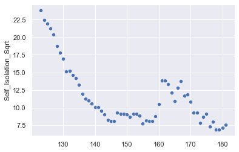

```
No data points after 2021-05-11 00:00:00
```

```python
gibraltar.predict_metric(gibraltar.infection_decline_second_dose.Day,
                         gibraltar.infection_decline_second_dose.Self_Isolation_Sqrt,
                         gibraltar.second_dose_date,
                         'Second Dose',
                         'Self-Isolation')
```

#### COVID Ward

```
                            OLS Regression Results
==============================================================================
Dep. Variable:        COVID_Ward_Sqrt   R-squared:                       0.698
Model:                            OLS   Adj. R-squared:                  0.692
Method:                 Least Squares   F-statistic:                     131.5
Date:                Sat, 10 Apr 2021   Prob (F-statistic):           1.97e-16
Time:                        20:59:13   Log-Likelihood:                -67.617
No. Observations:                  59   AIC:                             139.2
Df Residuals:                      57   BIC:                             143.4
Df Model:                           1
Covariance Type:            nonrobust
==============================================================================
                 coef    std err          t      P>|t|      [0.025      0.975]
------------------------------------------------------------------------------
const          3.4625      0.204     16.954      0.000       3.054       3.871
Day           -0.0679      0.006    -11.466      0.000      -0.080      -0.056
==============================================================================
Omnibus:                        2.740   Durbin-Watson:                   0.209
Prob(Omnibus):                  0.254   Jarque-Bera (JB):                2.644
Skew:                          -0.494   Prob(JB):                        0.267
Kurtosis:                       2.682   Cond. No.                         69.9
==============================================================================

Notes:
[1] Standard Errors assume that the covariance matrix of the errors is correctly specified.
y =  -0.06788566535946314 x +  3.4625111689467287
```

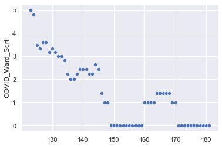

```
No data points after 2021-03-25 00:00:00
```

```python
gibraltar.predict_metric(gibraltar.infection_decline_second_dose.Day,
                         gibraltar.infection_decline_second_dose.COVID_Ward_Sqrt,
                         gibraltar.second_dose_date,
                         'Second Dose',
                         'COVID Ward Occupancy')
```

#### Critical Care

```
                            OLS Regression Results
==============================================================================
Dep. Variable:     Critical_Care_Sqrt   R-squared:                       0.954
Model:                            OLS   Adj. R-squared:                  0.953
Method:                 Least Squares   F-statistic:                     1174.
Date:                Sat, 10 Apr 2021   Prob (F-statistic):           1.02e-39
Time:                        20:59:13   Log-Likelihood:                -3.6577
No. Observations:                  59   AIC:                             11.32
Df Residuals:                      57   BIC:                             15.47
Df Model:                           1
Covariance Type:            nonrobust
==============================================================================
                 coef    std err          t      P>|t|      [0.025      0.975]
------------------------------------------------------------------------------
const          3.5168      0.069     50.913      0.000       3.379       3.655
Day           -0.0686      0.002    -34.257      0.000      -0.073      -0.065
==============================================================================
Omnibus:                        4.734   Durbin-Watson:                   0.423
Prob(Omnibus):                  0.094   Jarque-Bera (JB):                3.893
Skew:                          -0.609   Prob(JB):                        0.143
Kurtosis:                       3.316   Cond. No.                         69.9
==============================================================================

Notes:
[1] Standard Errors assume that the covariance matrix of the errors is correctly specified.
y =  -0.06859685085869628 x +  3.5168230528287037
```

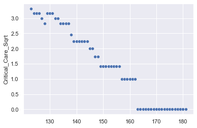

```
No data points after 2021-03-25 00:00:00
```

```python
gibraltar.predict_metric(gibraltar.infection_decline_second_dose.Day,
                         gibraltar.infection_decline_second_dose.Critical_Care_Sqrt,
                         gibraltar.second_dose_date,
                         'Second Dose',
                         'Critical Care Occupancy')
```

#### Emergency Room

```
                             OLS Regression Results
===============================================================================
Dep. Variable:     Emergency_Room_Sqrt   R-squared:                       0.575
Model:                             OLS   Adj. R-squared:                  0.567
Method:                  Least Squares   F-statistic:                     77.07
Date:                 Sat, 10 Apr 2021   Prob (F-statistic):           3.55e-12
Time:                         20:59:14   Log-Likelihood:                -63.596
No. Observations:                   59   AIC:                             131.2
Df Residuals:                       57   BIC:                             135.3
Df Model:                            1
Covariance Type:             nonrobust
==============================================================================
                 coef    std err          t      P>|t|      [0.025      0.975]
------------------------------------------------------------------------------
const          2.1795      0.191     11.424      0.000       1.797       2.562
Day           -0.0486      0.006     -8.779      0.000      -0.060      -0.037
==============================================================================
Omnibus:                        4.249   Durbin-Watson:                   0.235
Prob(Omnibus):                  0.119   Jarque-Bera (JB):                4.520
Skew:                           0.168   Prob(JB):                        0.104
Kurtosis:                       4.314   Cond. No.                         69.9
==============================================================================

Notes:
[1] Standard Errors assume that the covariance matrix of the errors is correctly specified.
y =  -0.04855122730150979 x +  2.1795219934797574
```

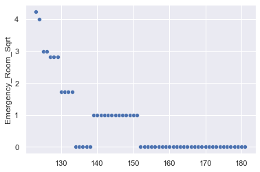

```
No data points after 2021-03-18 00:00:00
```

```python
gibraltar.predict_metric(gibraltar.infection_decline_second_dose.Day,
                         gibraltar.infection_decline_second_dose.Emergency_Room_Sqrt,
                         gibraltar.second_dose_date,
                         'Second Dose',
                         'Emergency Room Occupancy')
```

## Predictions Summary

A lag of about a week can be observed between emergency room occupancy and either COVID ward or critical care occupancy. Gibraltar appears to be enforcing a fairly lengthy self-isolation period. Self-isolation is expected to zero almost two months after the zero date of emergency room occupancy and about a month after active cases are expected to reach zero.

```python
predicted_dates = gibraltar.predicted_zero_date[gibraltar.predicted_zero_date.Dose == 'Second Dose'].copy()
predicted_dates = predicted_dates.sort_values(by = ['Zero Date'])
predicted_dates
```

|  | Dose | Metric | Zero Date |
| --- | --- | --- | --- |
| 9 | Second Dose | Emergency Room Occupancy | 2021-03-18 |
| 7 | Second Dose | COVID Ward Occupancy | 2021-03-25 |
| 8 | Second Dose | Critical Care Occupancy | 2021-03-25 |
| 5 | Second Dose | Active Cases | 2021-04-12 |
| 6 | Second Dose | Self-Isolation | 2021-05-11 |

## Metric Correlations

The greatest correlations exist between; daily cases, self-isolating cases, change in daily recovered cases, and active cases. The relationships between these metrics can be quantified with a predictability in low to mid 90% range.

```python
correlations = pd.DataFrame()
correlations['daily_cases'] = gibraltar.daily_cases
correlations['self_isolation'] = gibraltar.self_isolation
correlations['delta_recovered'] = gibraltar.delta_recovered
correlations['active_cases'] = gibraltar.active_cases
correlations.corr()
```

|  | daily_cases | self_isolation | delta_recovered | active_cases |
| --- | --- | --- | --- | --- |
| daily_cases | 1.000000 | 0.898101 | 0.510689 | 0.872178 |
| self_isolation | 0.898101 | 1.000000 | 0.637831 | 0.929928 |
| delta_recovered | 0.510689 | 0.637831 | 1.000000 | 0.772050 |
| active_cases | 0.872178 | 0.929928 | 0.772050 | 1.000000 |

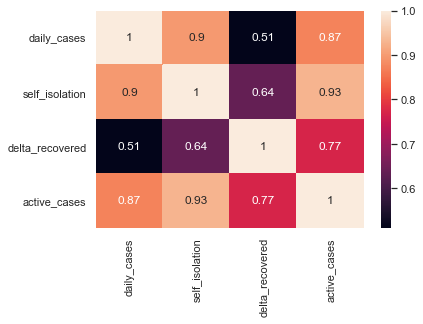

```python
sns.heatmap(correlations.corr(), annot = True)
plt.show()
```

#### Active Cases Target

```python
gibraltar.data = pd.DataFrame()
gibraltar.data['Daily_Cases'] = gibraltar.daily_cases
gibraltar.data['Self_Isolation'] = gibraltar.self_isolation
gibraltar.data['Delta_Recovered'] = gibraltar.delta_recovered

gibraltar.target = pd.DataFrame()
gibraltar.target['Active_Cases'] = gibraltar.active_cases

prediction_scores = []

for prediction_count in range(1, 10000):
    gibraltar.split_data()
    gibraltar.run_algorithm(Lasso())
    prediction_scores.append(gibraltar.prediction_score)

print('Maximum Accuracy:', np.max(prediction_scores))
print('Mean Accuracy:', np.mean(prediction_scores))
```

```
Maximum Accuracy: 0.9814686104316619
Mean Accuracy: 0.9166395928976744
```

#### Daily Cases Target

```python
gibraltar.data = pd.DataFrame()
gibraltar.data['Active_Cases'] = gibraltar.active_cases
gibraltar.data['Self_Isolation'] = gibraltar.self_isolation
gibraltar.data['Delta_Recovered'] = gibraltar.delta_recovered

gibraltar.target = pd.DataFrame()
gibraltar.target['Daily_Cases'] = gibraltar.daily_cases

prediction_scores = []

for prediction_count in range(1, 10000):
    gibraltar.split_data()
    gibraltar.run_algorithm(Lasso())
    prediction_scores.append(gibraltar.prediction_score)

print('Maximum Accuracy:', np.max(prediction_scores))
print('Mean Accuracy:', np.mean(prediction_scores))
```

```
Maximum Accuracy: 0.9733455627400088
Mean Accuracy: 0.8237216463419786
```

#### Self-Isolation Target

```python
gibraltar.data = pd.DataFrame()
gibraltar.data['Active_Cases'] = gibraltar.active_cases
gibraltar.data['Daily_Cases'] = gibraltar.daily_cases
gibraltar.data['Delta_Recovered'] = gibraltar.delta_recovered

gibraltar.target = pd.DataFrame()
gibraltar.target['Self_Isolation'] = gibraltar.self_isolation

prediction_scores = []

for prediction_count in range(1, 10000):
    gibraltar.split_data()
    gibraltar.run_algorithm(Lasso())
    prediction_scores.append(gibraltar.prediction_score)

print('Maximum Accuracy:', np.max(prediction_scores))
print('Mean Accuracy:', np.mean(prediction_scores))
```

```
Maximum Accuracy: 0.9677725757817611
Mean Accuracy: 0.8802496312595338
```

#### Recovered Delta Target

```python
gibraltar.data = pd.DataFrame()
gibraltar.data['Active_Cases'] = gibraltar.active_cases
gibraltar.data['Daily_Cases'] = gibraltar.daily_cases
gibraltar.data['Self_Isolation'] = gibraltar.self_isolation

gibraltar.target = pd.DataFrame()
gibraltar.target['Delta_Recovered'] = gibraltar.delta_recovered

prediction_scores = []

for prediction_count in range(1, 10000):
    gibraltar.split_data()
    gibraltar.run_algorithm(Lasso())
    prediction_scores.append(gibraltar.prediction_score)

print('Maximum Accuracy:', np.max(prediction_scores))
print('Mean Accuracy:', np.mean(prediction_scores))
```

```
Maximum Accuracy: 0.9339359486263117
Mean Accuracy: 0.6215044890994795
```

## Ratio Analysis

Infections begin to accelerate around the middle of December 2020 and begin to go into decline around the third week of January 2021.

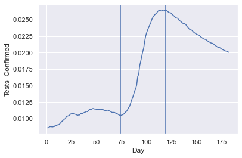

```python
tests_confirmed = gibraltar.file_data.Confirmed_Cases / gibraltar.file_data.Tests

tests_confirmed_df = pd.DataFrame()
tests_confirmed_df['Day'] = gibraltar.file_data.Day
tests_confirmed_df['Tests_Confirmed'] = tests_confirmed
sns.lineplot(x = tests_confirmed_df.Day, y = tests_confirmed_df.Tests_Confirmed)
plt.axvline(x = 74)
plt.axvline(x = 119)
plt.show()
```

Recovery time appears to be about twelve days.

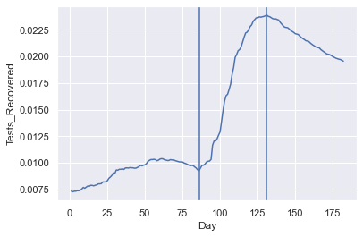

```python
tests_recovered = gibraltar.file_data.Recovered_Cases / gibraltar.file_data.Tests

tests_recovered_df = pd.DataFrame()
tests_recovered_df['Day'] = gibraltar.file_data.Day
tests_recovered_df['Tests_Recovered'] = tests_recovered
sns.lineplot(x = tests_recovered_df.Day, y = tests_recovered_df.Tests_Recovered)
plt.axvline(x = 86)
plt.axvline(x = 131)
plt.show()
```

The worst period in terms of acceleration of deaths was the month of January.

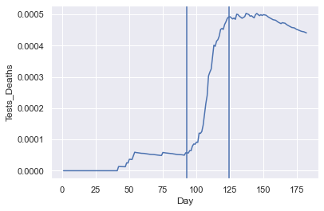

```python
tests_deaths = gibraltar.file_data.Total_Deaths / gibraltar.file_data.Tests

tests_deaths_df = pd.DataFrame()
tests_deaths_df['Day'] = gibraltar.file_data.Day
tests_deaths_df['Tests_Deaths'] = tests_deaths
sns.lineplot(x = tests_deaths_df.Day, y = tests_deaths_df.Tests_Deaths)
plt.axvline(x = 93)
plt.axvline(x = 124)
plt.show()
```

```
2021-01-14 00:00:00 0.16605004958261652
```

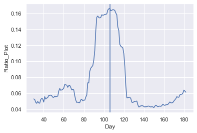

```python
gibraltar.ratio_plot(gibraltar.file_data_datetime.Results_Pending,
                     gibraltar.file_data_datetime.Daily_Tests,
                     'Pending Results to Daily Tests')
```

```
2021-01-18 00:00:00 2.0828978199886725
```

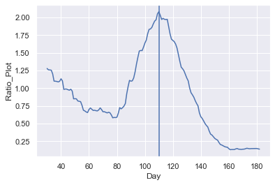

```python
gibraltar.ratio_plot(gibraltar.file_data_datetime.Self_Isolation,
                     gibraltar.file_data_datetime.Daily_Tests,
                     'Self-Isolation to Daily Tests')
```

```
2020-12-21 00:00:00 6.491056142257045
```

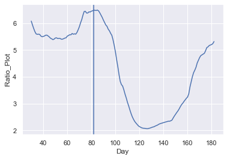

```python
gibraltar.ratio_plot(gibraltar.file_data_datetime.Self_Isolation,
                     gibraltar.file_data_datetime.Active_Cases,
                     'Self-Isolation to Active Cases')
```

```
2021-01-24 00:00:00 0.8428956465980472
```

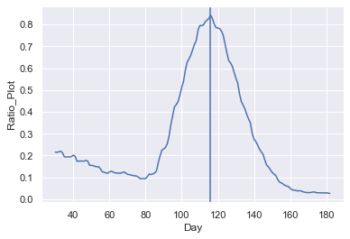

```python
gibraltar.ratio_plot(gibraltar.file_data_datetime.Active_Cases,
                     gibraltar.file_data_datetime.Daily_Tests,
                     'Active Cases to Daily Tests')
```

```
2021-02-01 00:00:00 0.08419062616274522
```

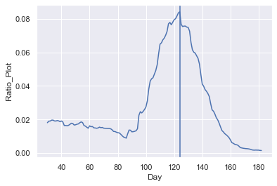

```python
gibraltar.ratio_plot(gibraltar.file_data_datetime.Delta_Recovered,
                     gibraltar.file_data_datetime.Daily_Tests,
                     'Delta Recovered to Daily Tests')
```

```
2021-02-14 00:00:00 0.07521148375206728
```

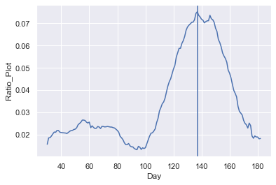

```python
gibraltar.ratio_plot(gibraltar.file_data_datetime.Delta_Recovered,
                     gibraltar.file_data_datetime.Self_Isolation,
                     'Delta Recovered to Self-Isolation')
```

```
2021-02-01 00:00:00 0.030387217948337538
```

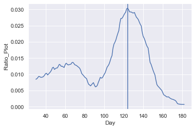

```python
gibraltar.ratio_plot(gibraltar.file_data_datetime.COVID_Ward,
                     gibraltar.file_data_datetime.Daily_Tests,
                     'COVID Ward to Daily Tests')
```

```
2021-01-31 00:00:00 0.07521599083337084
```

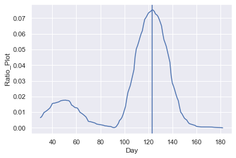

```python
gibraltar.ratio_plot(gibraltar.file_data_datetime.Emergency_Room,
                     gibraltar.file_data_datetime.Daily_Tests,
                     'Emergency Room to Daily Tests')
```